# “Tidy” RuFaS Output

Towards clean and highly usable temporal simulation data

Author

Clay J. Morrow

Published

June 23, 2026

Reviewers: Joseph Waddell, Kristan Reed  
Status: Draft

# Overview

The product that RuFaS ultimately provides is data, so it is important that those data are well-organized and useful to the end user with minimal effort. Currently, a tremendous amount of work is required to make the data usable. Even with a well-designed report filter, the resulting data products still require cleanup and organization. This document proposes an overhaul to the way that output data are represented within RuFaS, especially how those data are provided to the user.

# Context:

## Tidy data

The quotes below are from Hadley Wickham’s excellent article, [Tidy data](https://tidyr.tidyverse.org/articles/tidy-data.html), which outlines a standard for data semantics and structure that is widely used by data scientists across fields. The core of this proposal is to align RuFaS data to such standards, in order to vastly improve their utility.

> The principles of tidy data provide a standard way to organise data values within a dataset. A standard makes initial data cleaning easier because you don’t need to start from scratch and reinvent the wheel every time. The tidy data standard has been designed to facilitate initial exploration and analysis of the data, and to simplify the development of data analysis tools that work well together. Current tools often require translation. You have to spend time munging the output from one tool so you can input it into another.

> Tidy datasets and tidy tools work hand in hand to make data analysis easier, allowing you to focus on the interesting domain problem, not on the uninteresting logistics of data. A dataset is a collection of values, usually either numbers (if quantitative) or strings (if qualitative). Values are organised in two ways. Every value belongs to a variable and an observation. A variable contains all values that measure the same underlying attribute (like height, temperature, duration) across units. An observation contains all values measured on the same unit (like a person, or a day, or a race) across attributes.

> Tidy data is a standard way of mapping the meaning of a dataset to its structure. A dataset is messy or tidy depending on how rows, columns and tables are matched up with observations, variables and types. In tidy data:
> - Each variable is a column; each column is a variable.
> - Each observation is a row; each row is an observation.
> - Each value is a cell; each cell is a single value.

## Current Output

As a working example, I ran a default simulation but collected only crop and soil (and time) output data. The resulting file has 1246 columns and a maximum of 2556 rows. However, those counts are a bit misleading, since the CSV file is not rectangular: each column only contains as many rows as there are are observations *for that variable*. This type of output is functionally useless without additional information, since a row of the file does not represent the same thing across columns. Figure 1 shows the data dimensions. One thing to note from this figure is most columns have no data at all.

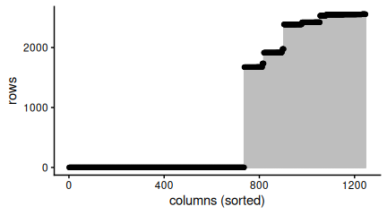

Figure 1: number of values returned for each column of RuFaS Data for a crop and soil run. The source of these data is a csv output file produced by a csv output filter.

The format of a “report” is a bit better, even one generated by a relatively simple filter file. The report data file is rectangular, but there are still the same empty columns. The more important issue with either form of the data is that the column labels are far too long and inconsistent. Table 1 contains a small subset of column labels. Note that each label contains more than a variable name: it also contains data about the measurement e.g., `(kg/ha)`, `field='field_1'`). Additionally, the structure of the labels is inconsistent and hard to parse: the first 4 follow a `MODULE_NAME.VARIABLE_NAME (UNITS)` pattern, the next 4 use `MODULE_NAME.CALLER_NAME.VARIABLE_NAME.GROUPING_DATA (UNITS)`, and the last 4 use `MODULE_NAME.CALLER_NAME.VARIABLE_GROUP.GROUPING_DATA.VARIABLE_NAME (UNITS)`. Moreover, the variables represented by labels 9-12 (when combined with an additional “planting_date” variable that I omitted) are redundant with those of 5-8.

```r
col_tab = tibble(label = names(CSV_data))

yield_cols = col_tab %>%
  filter(
    grepl("crop_daily_variables.yield", label)
  ) %>% head(n = 4)

alt_yield_cols = col_tab %>%
  filter(
    grepl("CropManagement.*(crop|nitrogen|phosphorus|field_name)", label)
  ) %>%
  filter(row_number() %in% c(1:3, 6))

time_cols = col_tab %>% filter(grepl("RufasTime", label))

col_sub <- bind_rows(time_cols, yield_cols, alt_yield_cols)

col_sub %>% mutate(id = row_number()) %>%
  relocate(label, .after = -1) %>%
  knitr::kable() %>%
  kable_styling(font_size = 8)
```

Table 1: A subset of RuFaS output column names

| id | label |
| --- | --- |
| 1 | RufasTime.day (julian day) |
| 2 | RufasTime.year (simulation year) |
| 3 | RufasTime.calendar_year (calendar year) |
| 4 | RufasTime.simulation_day (simulation day) |
| 5 | FieldDataReporter.send_crop_daily_variables.yield_nitrogen.field='field_1',crop='corn_silage',planted=127,2013 (kg/ha) |
| 6 | FieldDataReporter.send_crop_daily_variables.yield_phosphorus.field='field_1',crop='corn_silage',planted=127,2013 (kg/ha) |
| 7 | FieldDataReporter.send_crop_daily_variables.yield_nitrogen.field='field_2',crop='corn_grain',planted=127,2013 (kg/ha) |
| 8 | FieldDataReporter.send_crop_daily_variables.yield_phosphorus.field='field_2',crop='corn_grain',planted=127,2013 (kg/ha) |
| 9 | CropManagement._record_yield.harvest_yield.field='field_1'.crop (unitless) |
| 10 | CropManagement._record_yield.harvest_yield.field='field_1'.nitrogen (kg/ha) |
| 11 | CropManagement._record_yield.harvest_yield.field='field_1'.phosphorus (kg/ha) |
| 12 | CropManagement._record_yield.harvest_yield.field='field_1'.field_name (unitless) |

Thus, the RuFaS output data violates all 3 of the tidy data principles. Which helps to explain why they are so difficult to wrangle:

- Each *variable* is **not** a column, since variable information is stored in column labels; and each column is **not** a variable,since many columns contain no data beyond the label (i.e., invariant).
- Each *observation* is **not** a row and each row is **not** an observation, since each row represents a time point on which multiple bservations were made (i.e., measurements of separate fields in the same row).
- Each value is **not** a cell, since the same values are contained in multiple columns. It does appear that each cell contains only a single value, though.

## Why tidiness matters

There are a number of reasons why the current structure of output data is less then ideal:

- Because labels are long, they are difficult for humans to read and digest. When viewing these data, only one or two columns fit on a screen. This complicates a common analysis step to getting an initial understanding of the data.
- Because the labels are inconsistent, they are difficult for machines to parse (e.g., `regex`). A user might try to break down the labels into component parts (i.e., split them into variables like `MODULE_NAME`, `CALLER_NAME`, `VARIABLE_NAME`, `UNITS`, etc.), but this cannot be done without external information about how each label is structured.
- Similarly, manipulating data within the RuFaS framework suffers from lack of consistent a naming paradigm: Report filters can not use a universal pattern but instead must be tediously tailored to each variable individually.
- Because the structure of output data is atypical, it does not fit into existing analysis workflows and reporting formats without substantial alteration. Tidy output would reduce friction with external analysis tools and processes.

# Requirements

## Must Have

RuFaS should provide tabular data to users that conforms to the “tidy data” paradigm, with consistent structure:

- rows represent individual observations (a specific domain at a specific time). Exactly what constitutes an RuFaS observation is debatable, but it should *not* represent the entire farm at a moment in time.
- Columns represent individual variables (attributes of the observation). This includes grouping information like which field or pen an observation was made from.
- Column labels should also not contain information about the variable like code address (module name, caller function, etc.), units, or grouping variables (like field ID and crop name).
- Standardize the grouping of records (see example in the Pandas Integration section) by mandating that they **all** must include a common set of grouping variables including their code address (e.g., `MODULE_NAME`, `CALLER_NAME`). I suggest an additional required grouping variable called `DOMAIN` to further categorize observations.
- Similarly, **every** record must have time information (e.g., `simulation_day`) attached (see example in Pandas Integration). Measurements recorded outside of the main simulation should use negative time steps if they are time series (i.e., the burn-in period during herd initialization) or an explicit missing value (`numpy.nan`).
- Implement a check when a measurement is recorded to ensure that it isn’t going to overwrite an existing record. There can only ever be one measurement per $address \times group \times time$, and if there is a conflict, than another grouping variable – which collectively define the observation – needs to be added for that measurement.

## Nice to Have

- Utilize the benefits of tabular (and tidy) data internally with `pandas.DataFrame` objects (see sections about Data frames and Data frame memory usage) and their corresponding methods. This could reduce infrastructural complexity.
- Provide an *option* to separate outputs by grouping and domain: for example, produce one table of crop data that includes a row for each $field \times crop \times time$ combination and a column for each variable pertaining to crops that was measured, and produce a separate but similar table for soil data.
- Provide an *option* to utilize “look-up tables” ([junction table](https://database.guide/what-is-a-junction-table-in-sql/)). Using the previous example: both the crop and soil sub-tables would have a variable called “Field ID”. A separate look-up table containing all the invariant information about each field ID (field name, location, size, soil type, etc.) would be produced present.
- Allow users to perform post-processing operations (i.e., filtering, aggregating, saving subsets) *after* the simulations finish, rather than requiring all such steps be provided prior to execution. It is difficult for users to know which steps they will want to take before seeing the data and it is frustrating to-rerun the model to add/remove a single variable (for example).

# Existing Solution

See section on Current Output.

# Proposed Solution

## Data Frames

`pandas.DataFrames` (data frames) are an easy and efficient way to represent and manipulate data and have many aspects that make them an ideal option. They:

- efficiently store tabular data and can be made to conform to the “tidy” paradigm;
- have built-in operations for manipulating data like sorting, slicing, filtering, pivoting, reshaping, aggregating, etc. This can relieve some burden from RuFaS’s infrastructure (especially post-processing, reporting, etc.);
- have many methods for converting to and from (and saving/loading) other common formats (including json, csv, and python dictionaries);
- provide options to improve efficiency like compact data formats and “chunkification”;
- are very commonly used by data scientists and analytical tools. Anyone that has used pandas data frames will instantly be able to understand model results, rather than needing to learn atypical and esoteric output formats and filter schema.

### Pandas integration: modifying the Output Manager

Below is an example of how `pandas.DataFrame` (data frame) could fit into the existing `OutputManager` (OM) structure, without a major change in how data are added to its output pool. The key components are as follows:

1. `make_info_map` builds on the existing `info_map` framework but standardizes its structure to always include the code address and name of the variable, and optionally include additional grouping factors.
2. `add_to_pool` is a modified version of the OM’s `_add_to_pool` method. Here, keys of the pool are tuples (i.e., `(MODULE, CALLER, VARIABLE)`, via `_tuplize_info_map`) instead of concatenated strings (e.g., `MODULE.CALLER.VARIABLE`).
3. `fill_pool` runs a toy simulation, generating fake data and recording it in the pool at each time step. This function mimics how RuFaS methods record measurements internally. Note that some of the variables aren’t observed at every time step.
4. `frame_pool` constructs a data frame from each element in the data pool.
5. `stack_frames` combines all the data in the pool into a single large data frame.
6. `tidy_frame` converts the long-form stacked data frame into a wide-form tidy data frame.

```python
import pandas as pd

def make_info_map(module, caller, variable, **grouping_variables):
    return dict(
      module = module, caller = caller, variable = variable, **grouping_variables
    )

def _tuplize_info_map(info_map: dict, extract: bool = True) -> tuple:
    if not extract:
      info_map = info_map.copy()
    out_tuple = (
      info_map.pop("module"), info_map.pop("caller"), info_map.pop("variable")
    )
    return out_tuple

def add_to_pool(t: int, info_map: dict, value, pool: dict):
    map_copy: dict = info_map.copy()
    key = _tuplize_info_map(map_copy)
    element = dict(time = t, value = value, **map_copy)
    if not key in pool:
        pool[key] = []
    pool[key].append(element)

def fill_pool(
  info_maps: list[dict], ntime: int = 100, pool: dict = None, inplace=False
) -> dict:
    if pool is None:
        pool = {}
    else:
        pool = pool if inplace else pool.copy()

    for i, imap in enumerate(info_maps):
        for t in range(ntime):
            # skip even time steps for the last sixth of cases:
            if (i > len(info_maps) // 6) and (t % 2 == 0):
                continue
            x = (i + 1 * t * 0.1) + (i * 0.2)  # nonsense data that depends on i and t
            add_to_pool(t, info_map = imap, value = x, pool = pool)
    return pool

def frame_variable(module:str, caller:str, variable:str, values: list[dict]):
    data_frame = pd.DataFrame(values)
    # add address columns:
    data_frame[["module", "caller", "variable"]] = (module, caller, variable)
    return data_frame

def frame_pool(filled_pool: dict):
    return [frame_variable(*k, values=v) for k, v in filled_pool.items()]

def stack_frames(df_list: list[pd.DataFrame]):
    return pd.concat(df_list).reset_index(drop=True)

def tidy_frame(stacked: pd.DataFrame):
    # get group column names:
    addr = ["module", "caller", "time"]
    var, val = ("variable", "value")
    groups = [col for col in stacked.columns if col not in addr + [var, val]]
    index_cols = addr + groups
    # pivot to wide form:
    tidied = stacked.pivot(index=index_cols, columns=var, values=val)
    # get rid of the "variable" column index name:
    tidied = tidied.rename_axis(None, axis=1).sort_index()
    return tidied
```

To demonstrate how it works, we will use the following `cases` (a list of info maps), displayed as a data frame table in Table 2:

Table 2: Example cases. Each row contains a single info_map and missing values (nan) indicate that the key indicated by the column label is not present in the info_map

| case | module | caller | variable | field | crop |
| --- | --- | --- | --- | --- | --- |
| 0 | HerdManager | measure_consumption | total_mass_consumed | nan | nan |
| 1 | FieldManager | apply_manure | manure_mass_added | A | nan |
| 2 | FieldManager | measure_crops | nitrogen | A | corn |
| 3 | FieldManager | measure_crops | carbon | A | corn |
| 4 | FieldManager | measure_crops | nitrogen | A | alfalfa |
| 5 | FieldManager | measure_crops | carbon | A | alfalfa |
| 6 | FieldManager | measure_crops | nitrogen | B | alfalfa |
| 7 | FieldManager | measure_crops | carbon | B | alfalfa |

Next we’ll use these cases to generate a small data set to demonstrate structure. First, we’ll construct the list of data frames for each variable (`df_list`) and look at the printed output for the first and last elements:

```python
filled_pool = fill_pool(cases, ntime = 3)

df_list = frame_pool(filled_pool)

df_list[0]
```

```
   time  value       module               caller             variable
0     0    0.0  HerdManager  measure_consumption  total_mass_consumed
1     1    0.1  HerdManager  measure_consumption  total_mass_consumed
2     2    0.2  HerdManager  measure_consumption  total_mass_consumed
```

```python
df_list[-1]
```

```
   time  value field     crop        module         caller variable
0     1    3.7     A     corn  FieldManager  measure_crops   carbon
1     1    6.1     A  alfalfa  FieldManager  measure_crops   carbon
2     1    8.5     B  alfalfa  FieldManager  measure_crops   carbon
```

Next we combine the list of data frames into one big data frame via `stack_frames`, which utilizes the `pandas.concat` method. The resulting data frame is shown by Table 3. Note that this data frame is not yet tidy: each row represent a single measurement but not an observation:

```python
stacked = stack_frames(df_list)

from IPython.display import Markdown, display
Markdown(stacked.to_markdown(tablefmt = "reStructuredText"))
```

Table 3: Combined results table for all example observations. Each row represents a measurement (value) of a single varaible.

|  | time | value | module | caller | variable | field | crop |
| --- | --- | --- | --- | --- | --- | --- | --- |
| 0 | 0 | 0 | HerdManager | measure_consumption | total_mass_consumed | nan | nan |
| 1 | 1 | 0.1 | HerdManager | measure_consumption | total_mass_consumed | nan | nan |
| 2 | 2 | 0.2 | HerdManager | measure_consumption | total_mass_consumed | nan | nan |
| 3 | 0 | 1.2 | FieldManager | apply_manure | manure_mass_added | A | nan |
| 4 | 1 | 1.3 | FieldManager | apply_manure | manure_mass_added | A | nan |
| 5 | 2 | 1.4 | FieldManager | apply_manure | manure_mass_added | A | nan |
| 6 | 1 | 2.5 | FieldManager | measure_crops | nitrogen | A | corn |
| 7 | 1 | 4.9 | FieldManager | measure_crops | nitrogen | A | alfalfa |
| 8 | 1 | 7.3 | FieldManager | measure_crops | nitrogen | B | alfalfa |
| 9 | 1 | 3.7 | FieldManager | measure_crops | carbon | A | corn |
| 10 | 1 | 6.1 | FieldManager | measure_crops | carbon | A | alfalfa |
| 11 | 1 | 8.5 | FieldManager | measure_crops | carbon | B | alfalfa |

This `variable`-`value` structure can be very useful for some processes, but to align with the tidy paradigm, we must pivot the variable column. This is done with `tidy_frame`. Table 4 shows the raw data frame produced by this function. This table is tidy, since each observation (unique grouping) is represented by a row (`nitrogen` and `carbon` measurements co-occur for crop fields on which both were measured):

```python
tidy_df = tidy_frame(stacked)
tidy_df
```

Table 4

```
                                                     carbon  manure_mass_added  nitrogen  total_mass_consumed
module       caller              time field crop
FieldManager apply_manure        0    A     nan         NaN                1.2       NaN                  NaN
                                 1    A     nan         NaN                1.3       NaN                  NaN
                                 2    A     nan         NaN                1.4       NaN                  NaN
             measure_crops       1    A     alfalfa     6.1                NaN       4.9                  NaN
                                            corn        3.7                NaN       2.5                  NaN
                                      B     alfalfa     8.5                NaN       7.3                  NaN
HerdManager  measure_consumption 0    nan   nan         NaN                NaN       NaN                  0.0
                                 1    nan   nan         NaN                NaN       NaN                  0.1
                                 2    nan   nan         NaN                NaN       NaN                  0.2
```

Note that the labels for the grouping variables (`module` – `crop`) are displayed on a separate line from the other variable labels (`carbon` – `total_mass_consumed`). That is because the grouping variables are a multi-column index (see this [MultiIndex guide](https://pandas.pydata.org/pandas-docs/stable/user_guide/advanced.html)). To convert this back into a regular flat table we can use the `reset_index` data frame method (results shown in Table 5):

```python
Markdown(
  tidy_df.reset_index().to_markdown()
)
```

Table 5: Tidy table of combined results, with one row per observation, and one column per variable, including grouping variables.

|  | module | caller | time | field | crop | carbon | manure_mass_added | nitrogen | total_mass_consumed |
| --- | --- | --- | --- | --- | --- | --- | --- | --- | --- |
| 0 | FieldManager | apply_manure | 0 | A | nan | nan | 1.2 | nan | nan |
| 1 | FieldManager | apply_manure | 1 | A | nan | nan | 1.3 | nan | nan |
| 2 | FieldManager | apply_manure | 2 | A | nan | nan | 1.4 | nan | nan |
| 3 | FieldManager | measure_crops | 1 | A | alfalfa | 6.1 | nan | 4.9 | nan |
| 4 | FieldManager | measure_crops | 1 | A | corn | 3.7 | nan | 2.5 | nan |
| 5 | FieldManager | measure_crops | 1 | B | alfalfa | 8.5 | nan | 7.3 | nan |
| 6 | HerdManager | measure_consumption | 0 | nan | nan | nan | nan | nan | 0 |
| 7 | HerdManager | measure_consumption | 1 | nan | nan | nan | nan | nan | 0.1 |
| 8 | HerdManager | measure_consumption | 2 | nan | nan | nan | nan | nan | 0.2 |

This data set was relatively simple to demonstrate the methods, but in practice variable names will likely need to be a bit more specific (`YieldCarbon` instead of `carbon`) and an additional `domain` grouping variable (or similar) should be added to indicate the system the observation belongs to. This would help differentiate similarly named variables taken from different systems. Some examples of `domain` values might be “crop production”, “crop storage”, “soil dynamics”, “animal dynamics”, etc.

### Data frame memory usage:

`pandas` data frames are highly memory-efficient objects. You may be surprised to learn that the data frame objects take up about the same space as the raw data dictionary, and the tidy data frames are much smaller (Table 6):

```python
from pympler.asizeof import asizeof

# make some data objects:
big_pool = fill_pool(cases, ntime = 10000)
big_list = frame_pool(big_pool)
big_stacked = stack_frames(big_list)
big_tidy = tidy_frame(big_stacked)

sizes = pd.Series({
  "pool dictionary": asizeof(big_pool),
  "data frame list": asizeof(big_list),
  "long stacked data frame": asizeof(big_stacked),
  "long stacked data frame (``pandas`` estimate)": sum(big_stacked.memory_usage(deep = True)),
  "tidy stacked data frame": asizeof(big_tidy),
  "tidy stacked data frame (``pandas`` estimate)": sum(big_tidy.memory_usage(deep = True)),
})

Markdown(
  pd.DataFrame(sizes/1e6, columns = ["size (MB)"]).reset_index(
    names = "source"
  ).to_markdown()
)
```

|  | source | size (MB) |
| --- | --- | --- |
| 0 | pool dictionary | 12.3818 |
| 1 | data frame list | 13.6643 |
| 2 | long stacked data frame | 14.6213 |
| 3 | long stacked data frame (`pandas` estimate) | 14.6201 |
| 4 | tidy stacked data frame | 1.41188 |
| 5 | tidy stacked data frame (`pandas` estimate) | 1.41075 |

It should be noted that while the tidy data frame objects are much smaller for this case, the relative performance also depends upon the number of columns in the data (which are less efficient than rows). Additionally, some operations require internally copying objects. During those operations, memory usage may be 2x (or more) the object size.

## Grouped tables with lookup tables

A common way to organize large complex datasets with measurements across different observational levels is to separate the data into sub-tables and lookup tables based on the observational units. Each data point is grouped into tables with other similar data (i.e., measured at the same scale, with the same set of variables). For example, an “Animal Measurements” table would contain all the data collected from individual cows across all time points (size, consumption, milk production, etc.). A separate table, “Pen information” would contain the data about the pens in which the animals are kept (size, location, bedding type, etc.). The tables would have a common “pen ID” variable that links the individual cows to a pen at a given point in time. Each of these tables would follow the “tidy” paradigm.

In addition to these grouped data tables, lookup table(s) would be included to store information about the variables measured. This table would include a row for each variable and would include (meta) variables/columns including:

- Variable ID: the unique numeric identifier of the variable
- Variable name: the name of the variable as it appears (as a column label) in the referenced source data table
- Units: the units associated with this variable (e.g., kg/ha, cm, lbs, etc.)
- Description: a description of what the variable measures, how it is measured, and any context for this variable
- Source table: a reference to the data table (`domain`) in which the variable can be found (e.g., “Animal Measurements”, “Pen information”).

In addition to the organizational benefits that this structure would provide, it can also improve the filtering process. For example, a table containing all the variable names and their information could easily be used to select individual variables, or groups thereof, for inclusion in reports out output. For example, I could select all variables from specific domain(s) (expression: `domain == "crop harvest"`), whose names match a pattern (expression: `re.search("cow_.*", variable_name)`), or which come from a particular location in the code (expression: `module == "CropSoil" & caller == "record_soil_variables"`).

# Alternative Solutions

- The proposed solution above attempts to reduce the changes to the way RuFaS currently collects output, but it is possible that an alternative method tailored to data frames (and `pandas.Series`) could be more efficient.
- Manually create the infrastructure that produces tidy data frames as described here.

# Milestones

- TBD

# Testability, Monitoring, and Alerting

- TBD

# Cross-Team Impact

This would affect all downstream processes, including output filtering and current analytical processes. Backwards compatibility would be very difficult and likely not worthwhile, as the benefits would greatly outweigh negatives for users.

# Open Questions

- Are there performance costs?
- TBD

# Detailed Scoping and Timeline

- TBD, likely requires a major version.